## Výber dát

V tejto domácej úlohe budeme pracovať s datasetom s názvom *Hawaii tourism* zo stránky https://dasl.datadescription.com/datafile/hawaii-tourism/?_sf_s=time+series&_sfm_cases=4+59943. Dataset obsahuje počty amerických turistov na Hawaii. Budeme pracovať so stĺpcom *total* vyjadrujúcim celkové počty turistov. Stiahnuté dáta sú mesačné, začínajú v januári 2002 a končia v decembri 2006, pričom my si posledný rok dát odložíme na zhodnotenie predikcií. Budeme teda pracovať s kratším časovým radom mapujúcim roky 2002 - 2005. Po načítaní dát si ich zobrazíme na grafe, aby sme si graficky overili, či v nich bude sezónnosť.

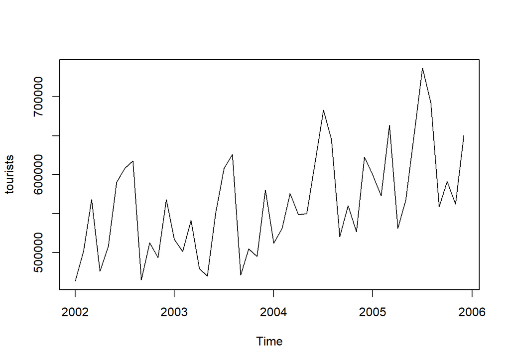

```r
data <- read.table("C:\\Users\\Public\\hawaii-tourism.txt", header=TRUE, sep= "\t")
tourists_kreslenie <- ts(data$Total, start = c(2002,1), frequency = 12)
tourists <- ts(data$Total, start = c(2002,1), frequency = 12)
tourists.pred <- window(tourists, start=c(2006,1))
tourists <- window(tourists, end=c(2005,12))
plot(tourists)
```

Z obrázka sledujeme, že sezónnosť by sme tu mohli očakávať, keďže počty turistov rastú hlavne v strede roka (mesiace jún, júl a august). Naopak najmenej turistov pozorujeme na jeseň. Navyše v dátach sledujeme rastúci trend. Z toho dôvodu musíme dáta prvýkrát diferencovať. Na základe nasledujúceho grafu, ktorý zobrazuje zdiferencované dáta usudzujeme, že trend sa nám podarilo odstrániť. Vidíme tiež, že dáta kmitajú okolo nejakej kladnej hodnoty (priemer dát je znázornený červenou čiarou).

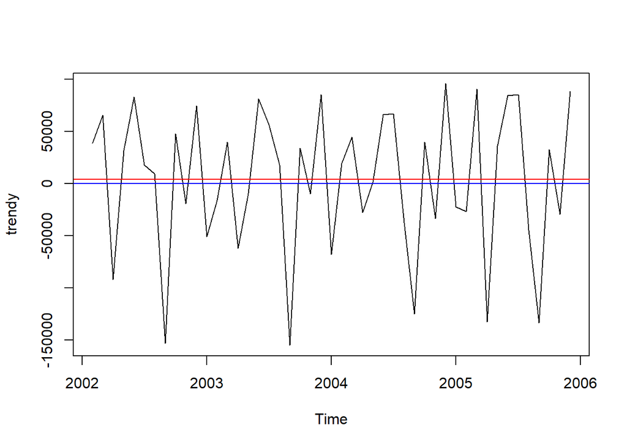

```r
trendy <- diff(tourists)
plot(trendy)
abline(h=mean(trendy), col="red")
abline(h=0, col="blue")
```

Teraz sa ešte pozieme na to, či máme v dátach jednotkový koreň.

```r
library(urca)
test <- ur.df(trendy,lags = 12,type = "drift",selectlags = "BIC")
summary(test)
```

```
##
## ###############################################
## # Augmented Dickey-Fuller Test Unit Root Test #
## ###############################################
##
## Test regression drift
##
##
## Call:
## lm(formula = z.diff ~ z.lag.1 + 1 + z.diff.lag)
##
## Residuals:
##    Min     1Q Median     3Q    Max
## -51453 -14947   3843  17434  49787
##
## Coefficients:
##                Estimate Std. Error t value Pr(>|t|)
## (Intercept)  12535.9370  7209.1424   1.739   0.0967 .
## z.lag.1         -4.7168     2.0114  -2.345   0.0289 *
## z.diff.lag1      3.2274     1.8642   1.731   0.0981 .
## z.diff.lag2      2.8260     1.7074   1.655   0.1128
## z.diff.lag3      2.3531     1.5508   1.517   0.1441
## z.diff.lag4      1.8687     1.3964   1.338   0.1951
## z.diff.lag5      1.5240     1.2264   1.243   0.2277
## z.diff.lag6      1.1364     1.0587   1.073   0.2953
## z.diff.lag7      0.8316     0.8909   0.933   0.3612
## z.diff.lag8      0.5977     0.7131   0.838   0.4113
## z.diff.lag9      0.2493     0.5396   0.462   0.6488
## z.diff.lag10    -0.1977     0.3771  -0.524   0.6056
## z.diff.lag11    -0.5053     0.1952  -2.589   0.0171 *
## ---
## Signif. codes:  0 '***' 0.001 '**' 0.01 '*' 0.05 '.' 0.1 ' ' 1
##
## Residual standard error: 31980 on 21 degrees of freedom
## Multiple R-squared:  0.945,  Adjusted R-squared:  0.9135
## F-statistic: 30.05 on 12 and 21 DF,  p-value: 1.68e-10
##
##
## Value of test-statistic is: -2.345 2.8009
##
## Critical values for test statistics:
##       1pct  5pct 10pct
## tau2 -3.58 -2.93 -2.60
## phi1  7.06  4.86  3.94
```

Z výsledku vidíme, že hypotézu o jednotkovom koreni zamietať nebudeme, nakoľko testová štatistika vyšla rovná -2.345, čo je viac ako kritická hodnota, ktorá v tomto prípade vyšla rovná -2.93. Naviac, v *ur.df* teste nám vyšlo veľa regresorov, preto budeme dáta diferencovať nie klasicky, ale sezónne.

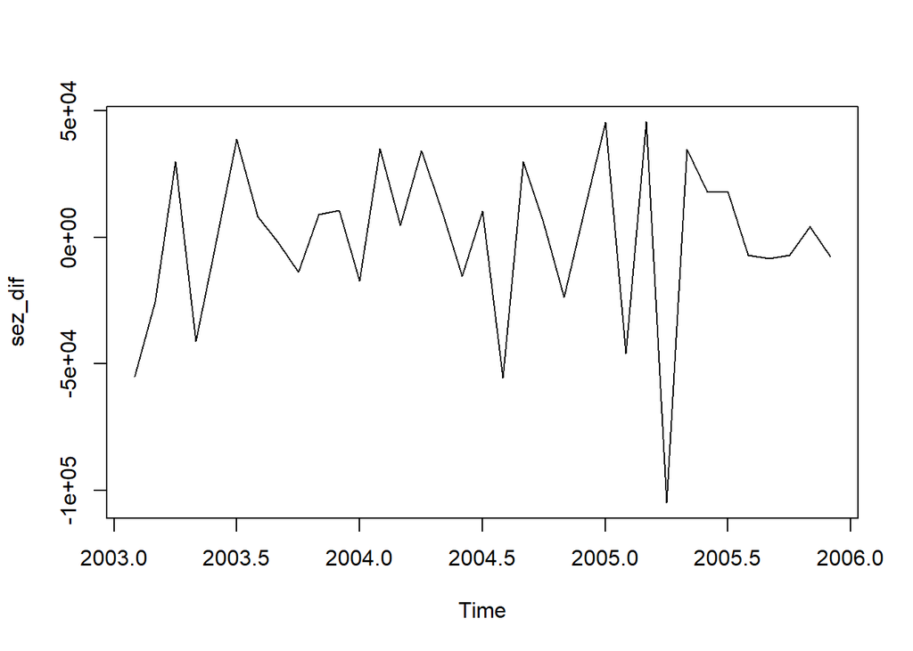

```r
sez_dif<- diff(trendy, lag = 12)
plot(sez_dif)
```

Vidíme, že z dát sa nám odstránila sezónnosť a už aj trend. Pre istotu však ešte raz aplikujeme test o jednotkovom koreni, aby sme si boli istí, že dáta už skutočne netreba diferencovať.

```r
test2 <- ur.df(sez_dif, lags = 12, type = "drift", selectlags = "BIC")
summary(test2)
```

```
##
## ###############################################
## # Augmented Dickey-Fuller Test Unit Root Test #
## ###############################################
##
## Test regression drift
##
##
## Call:
## lm(formula = z.diff ~ z.lag.1 + 1 + z.diff.lag)
##
## Residuals:
##    Min     1Q Median     3Q    Max
## -83579 -12346    290  22299  49491
##
## Coefficients:
##               Estimate Std. Error t value Pr(>|t|)
## (Intercept)  873.79100 6774.42581   0.129 0.898726
## z.lag.1       -1.53680    0.39241  -3.916 0.000928 ***
## z.diff.lag     0.02598    0.22461   0.116 0.909119
## ---
## Signif. codes:  0 '***' 0.001 '**' 0.01 '*' 0.05 '.' 0.1 ' ' 1
##
## Residual standard error: 31670 on 19 degrees of freedom
## Multiple R-squared:  0.7592, Adjusted R-squared:  0.7338
## F-statistic: 29.95 on 2 and 19 DF,  p-value: 1.337e-06
##
##
## Value of test-statistic is: -3.9163 7.6849
##
## Critical values for test statistics:
##       1pct  5pct 10pct
## tau2 -3.58 -2.93 -2.60
## phi1  7.06  4.86  3.94
```

Hypotézu o jednotkovom koreni naozaj môžeme zamietnuť, keďže testová štatistika je menšia ako 5% kritická hodnota testu. Teraz si vykreslíme autokorelačnú aj parciálnu autokorelačnú testu, aby sme vedeli odhadnúť vhodný sarima model.

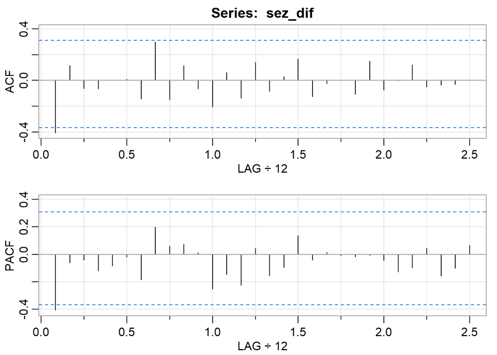

```
##       [,1]  [,2]  [,3]  [,4]  [,5]  [,6]  [,7] [,8]  [,9] [,10] [,11] [,12]
## ACF  -0.41  0.11 -0.06 -0.06  0.00  0.01 -0.14  0.3 -0.15  0.12 -0.07 -0.20
## PACF -0.41 -0.06 -0.04 -0.12 -0.08 -0.02 -0.18  0.2  0.06  0.07  0.01 -0.25
##      [,13] [,14] [,15] [,16] [,17] [,18] [,19] [,20] [,21] [,22] [,23] [,24]
## ACF   0.06 -0.14  0.14 -0.08  0.03  0.17 -0.12 -0.02  0.01 -0.11  0.15 -0.07
## PACF -0.15 -0.23  0.05 -0.15 -0.09  0.14 -0.04  0.02 -0.01 -0.02 -0.01 -0.04
##      [,25] [,26] [,27] [,28] [,29] [,30]
## ACF   0.00  0.12 -0.05 -0.03 -0.03  0.00
## PACF -0.13 -0.10  0.05 -0.16 -0.10  0.07
```

```r
library(astsa)
acf2(sez_dif, max.lag = 30)
```

Z autokorelačnej a parciálnej autokorelačnej funkcie vidíme, že by sa mohlo jednať o AR(1), prípadne MA(1) model, keďže z intervalu spoľahlivosti vychádzame pre acf aj pacf iba pri prvom lagu. My vyskúšame oba modely, navyše prihodíme aj nejaký sezónny AR a MA člen. Kvalitu testov porovnáme vzhľadom na Bayesovo informačné kritérium.

```r
ar1 <- sarima(tourists, p=0, d=1, q=1, P=0, D=1, Q=0, S=12, details = FALSE)
ma1 <- sarima(tourists, p=1, d=1, q=0, P=0, D=1, Q=0, S=12, details = FALSE)
arma11 <- sarima(tourists, p=1, d=1, q=1, P=0, D=1, Q=0, S=12,details = FALSE)
a1s1 <- sarima(tourists, p=1, d=1, q=0, P=1, D=1, Q=0, S=12, details = FALSE)
m1sm1 <- sarima(tourists, p=0, d=1, q=1, P=0, D=1, Q=1, S=12, details = FALSE)
sarima11 <- sarima(tourists, p=1, d=1, q=1, P=1, D=1, Q=1, S=12,details = FALSE)

ar1$BIC
```

```
## [1] 23.55556
```

```r
ma1$BIC
```

```
## [1] 23.58423
```

```r
arma11$BIC
```

```
## [1] 23.65497
```

```r
a1s1$BIC
```

```
## [1] 23.5029
```

```r
m1sm1$BIC
```

```
## [1] 23.42655
```

```r
sarima11$BIC
```

```
## [1] 23.59996
```

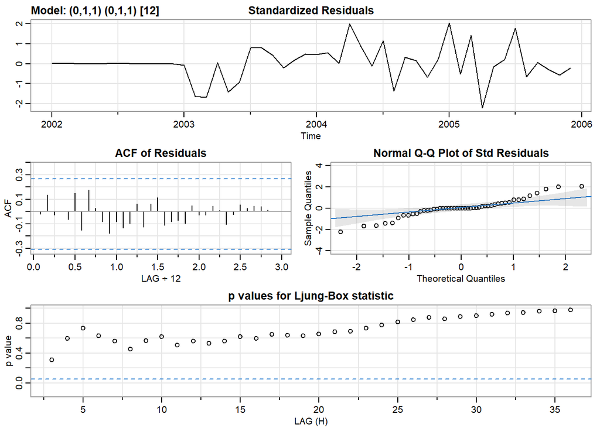

```
## $fit
##
## Call:
## arima(x = xdata, order = c(p, d, q), seasonal = list(order = c(P, D, Q), period = S),
##     include.mean = !no.constant, transform.pars = trans, fixed = fixed, optim.control = list(trace = trc,
##         REPORT = 1, reltol = tol))
##
## Coefficients:
##           ma1     sma1
##       -0.6307  -0.9993
## s.e.   0.1369   1.1564
##
## sigma^2 estimated as 398359067:  log likelihood = -404.63,  aic = 815.26
##
## $degrees_of_freedom
## [1] 33
##
## $ttable
##      Estimate     SE t.value p.value
## ma1   -0.6307 0.1369 -4.6054  0.0001
## sma1  -0.9993 1.1564 -0.8642  0.3937
##
## $AIC
## [1] 23.29323
##
## $AICc
## [1] 23.30394
##
## $BIC
## [1] 23.42655
```

```r
sarima(tourists, p=0, d=1, q=1, P=0, D=1, Q=1, S=12)
```

Ako vidíme, najvhodnejším modelom z uvedených bude SARIMA model s MA(1) členom a so sezónnym SMA(1) členom. Tento model následne použijeme pri predikovaní. Predikcie budeme robiť na rok dopredu, keďže sme takú istú dĺžku odsekli na začiatku.

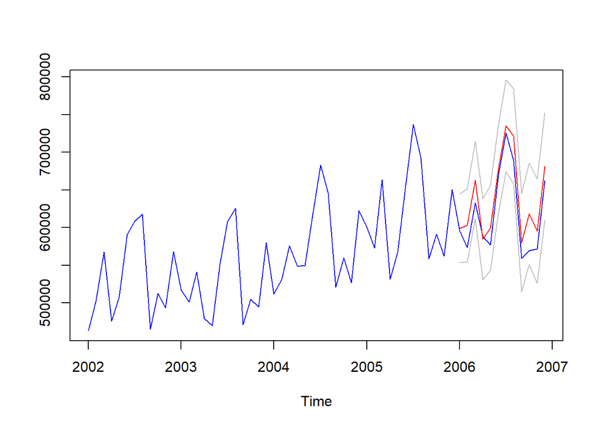

```r
odhad <- sarima.for(tourists,n.ahead = 12, p=0, d=1, q=1, P=0, D=1, Q=1, S=12,plot = FALSE)
ts.plot(tourists_kreslenie,odhad$pred,odhad$pred+2*odhad$se,odhad$pred-2*odhad$se,col=c("blue","red","grey","grey"))
```

V záverečnej časti spravíme ešte predikcie pomocou Holt-Wintersovej metódy. Ešte z prvého zobrazenia dát vidíme, že sa bude jednať o aditívnu sezónnosť a nie multiplikatívnu, nakoľko nesledujeme rastúcu disperziu.

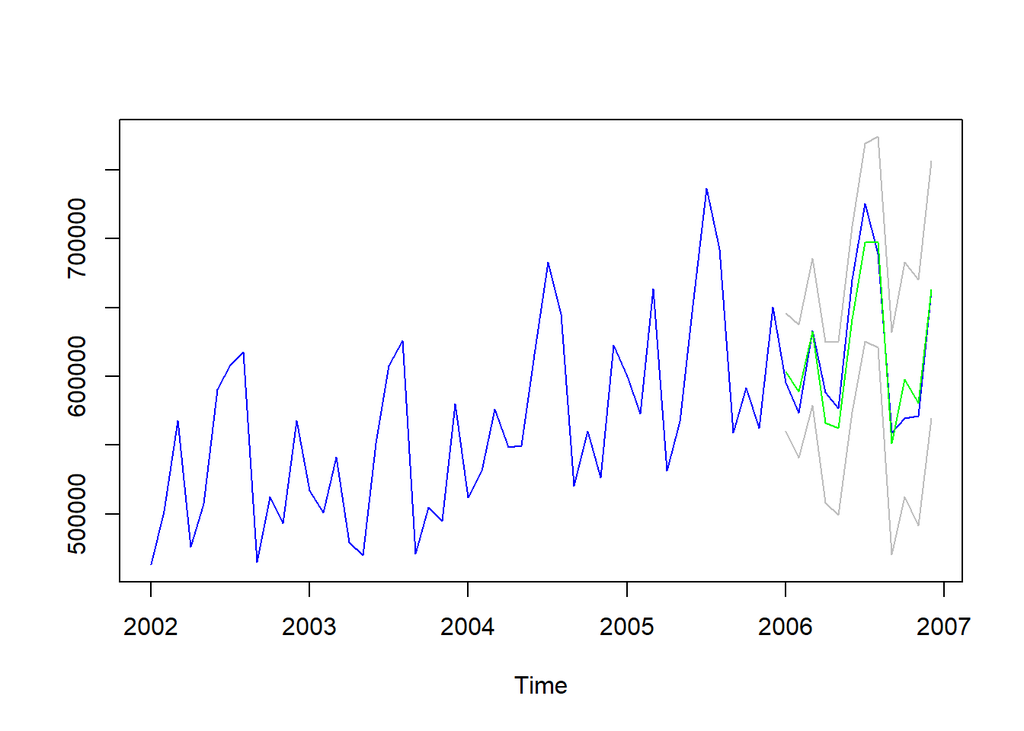

```r
winters <- HoltWinters(tourists, seasonal = "additive")
pred <- predict(winters, n.ahead=12, prediction.interval=TRUE)
pallete <- c("blue", "green", "gray", "gray")
ts.plot(tourists_kreslenie, pred, col=pallete)
```

Na záver si vykreslíme do spoločného grafu predikcie nájdené oboma metódami.

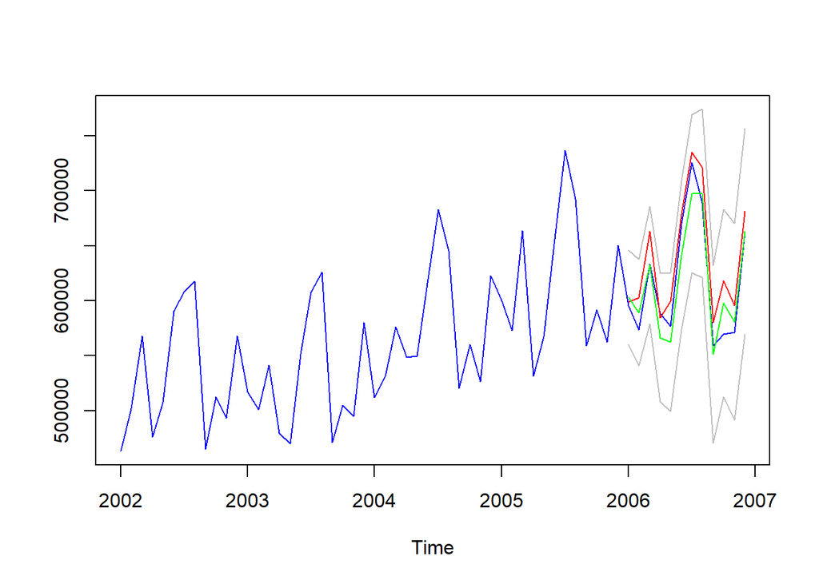

```r
ts.plot(tourists_kreslenie, odhad$pred, pred, col=c("blue","red","green", "gray", "gray"))
```

Z vysledkov predikcií môžeme sledovať, že ako pomocou sarima modelu, tak aj pomocou Holt wintersovej metódy, skutočné dáta sa trafili do nájdených predikčných intervalov. Teda predikcie považujeme za dobré. Naviac pozorujeme, že predikcie nám pri oboch použitých metódach vyšli veľmi podobne.